# Course Project 1 - Reproducible Research

Vivek Joshi

March 31, 2017

## Loading/Reading in the Data

```r
setwd("C:\\Users\\vivek\\Documents\\Data Science\\Coursera\\05 - Reproducible Research\\Lecture 02")
download.file("https://d396qusza40orc.cloudfront.net/repdata%2Fdata%2Factivity.zip", "project.zip")
df <- read.csv(unz("project.zip", "activity.csv"))
file.remove("project.zip")
```

```
## [1] TRUE
```

## Histogram of the total number of steps taken per day

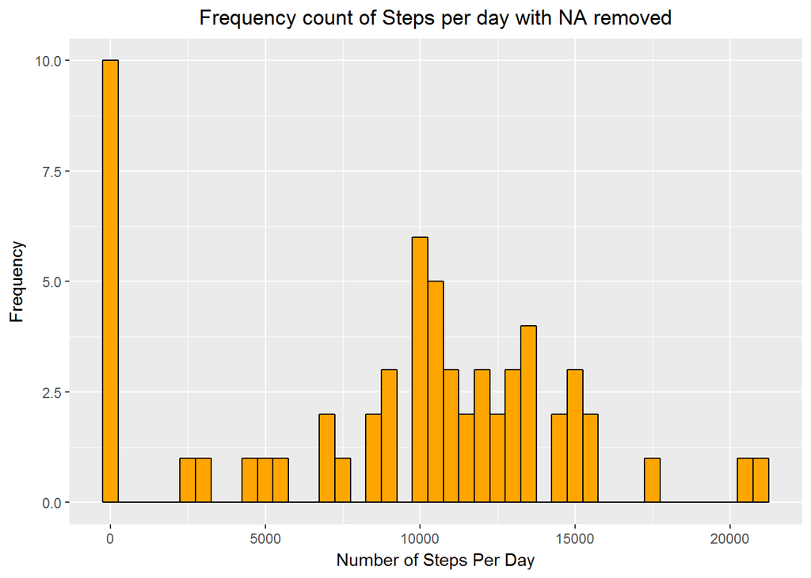

```r
dplyr_tot <- df %>%
  group_by(date) %>%
  summarise(daily = sum(steps, na.rm = TRUE))
ggplot(dplyr_tot, aes(daily)) +
  geom_histogram(binwidth = 500, fill="orange", colour="black") +
  xlab("Number of Steps Per Day") +
  ylab("Frequency") +
  ggtitle("Frequency count of Steps per day with NA removed") +
  theme(plot.title = element_text(hjust = 0.5))
```

Average number of steps taken per day is : 9354.23

## Time series plot of the average number of steps taken

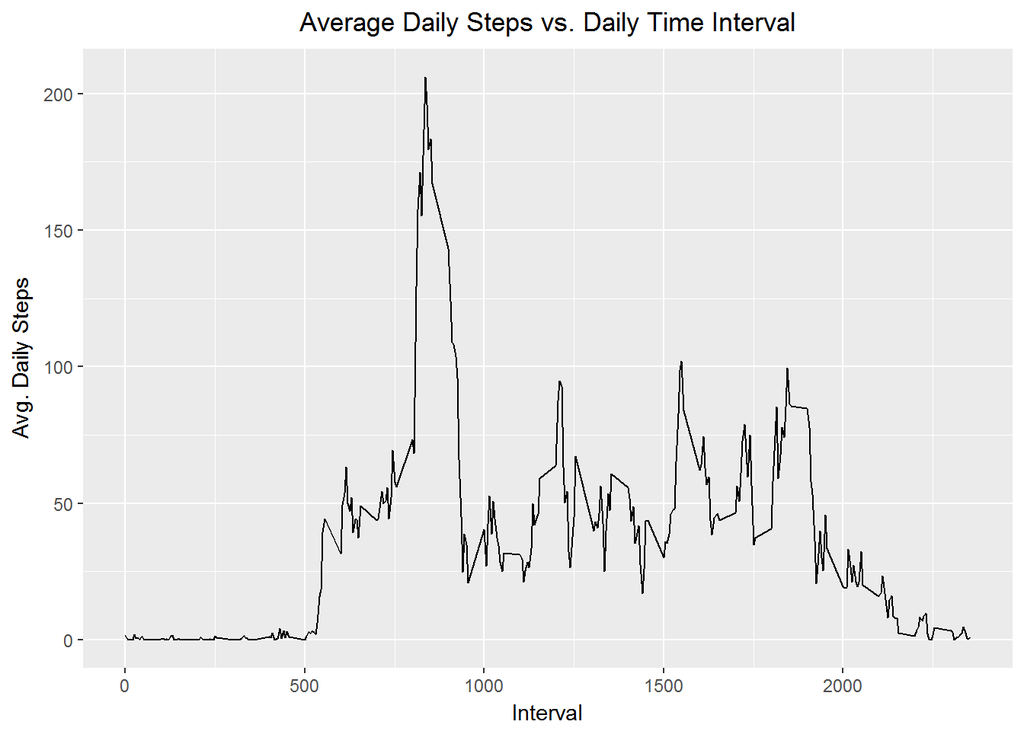

```r
df.avg.steps <- df %>%
  group_by(interval) %>%
  summarise(avg.steps = mean(steps, na.rm = TRUE))

ggplot(df.avg.steps, aes(interval, avg.steps)) + geom_line() +
  xlab("Interval") + ylab("Avg. Daily Steps") +
  ggtitle("Average Daily Steps vs. Daily Time Interval") +
  theme(plot.title = element_text(hjust = 0.5))
```

## Five minute interval that on the average has the max number of steps

Five minute interval with the max number of steps is : 835

## Code to describe imputation strategy

The data above has a wide distribution, hence I have chosen to use the median value for the same interval for interpolation. Another thing that could be done is to impute on the basis of time interval and whether it is a weekend or weekday, but I have not performed that analysis. To check whether the median for imputation makes sense, we can check with the summary command

```r
summary(df$steps)
```

```
##    Min. 1st Qu.  Median    Mean 3rd Qu.    Max.    NA's
##    0.00    0.00    0.00   37.38   12.00  806.00    2304
```

Moving on for the imputation yields

```r
df.nona <- df # copy the dataframe, will clean and use...
where.nas <- is.na(df.nona$steps)
# compute median over interval, since data has "wide" distribution.
impute.time <- tapply(df.nona$steps, df.nona$interval, median, na.rm = TRUE, simplify = TRUE)
df.nona$steps[where.nas] <- impute.time[as.character(df.nona$interval[where.nas])]
# check for no NAs
sum(is.na(df.nona))
```

```
## [1] 0
```

## Histogram of the total number of steps taken each day after missing values are imputed

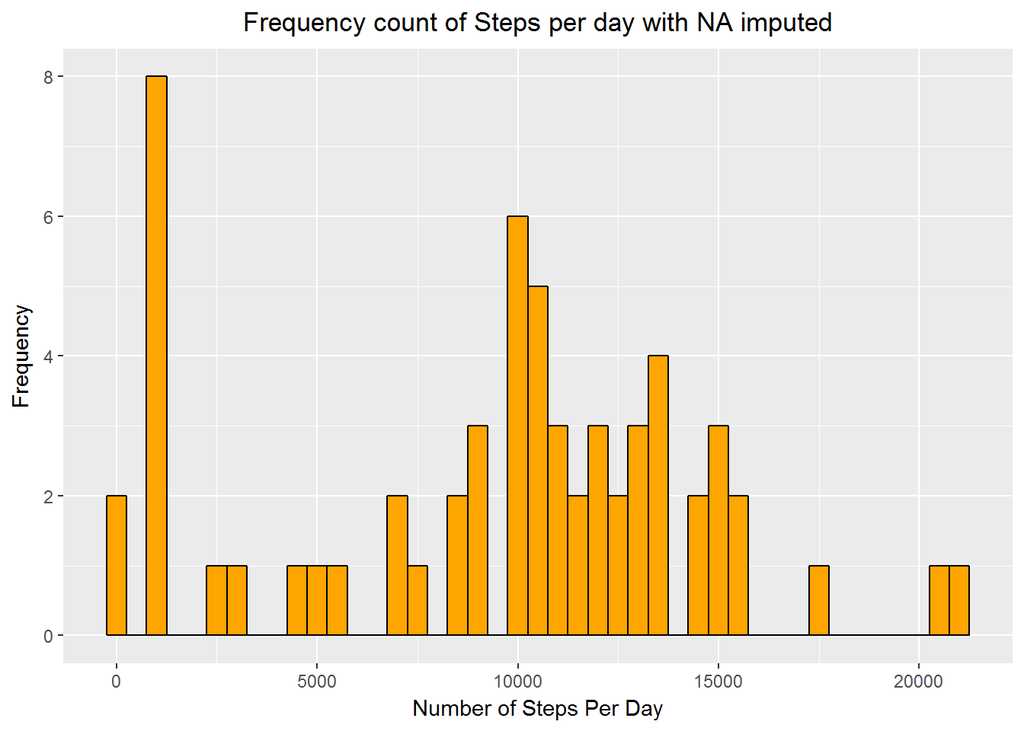

```r
dplyr.nona.tot <- df.nona %>%
  group_by(date) %>%
  summarise(daily = sum(steps, na.rm = TRUE))

# can use tapply too
# total.steps <- tapply(df$steps, df$date, FUN=sum, na.rm=TRUE, simplify = TRUE)
ggplot(dplyr.nona.tot, aes(daily)) +
  geom_histogram(binwidth = 500, fill="orange", colour="black") +
  xlab("Number of Steps Per Day") +
  ylab("Frequency") +
  ggtitle("Frequency count of Steps per day with NA imputed") +
  theme(plot.title = element_text(hjust = 0.5))
```

[figure not shown]

```r
# convert date to Date type so can use weekday
df.nona$date <- as.Date(df.nona$date)
df.nona <- df.nona %>%
  mutate(daytype = ifelse(weekdays(df.nona$date) %in% c("Saturday","Sunday"), "Weekend", "Weekday"))


df.nona <- df.nona %>%
  group_by(interval) %>%
  mutate(avg.steps = mean(steps, na.rm = TRUE))

ggplot(df.nona, aes(x =interval , y=steps, color=daytype)) +
  geom_line() +
  labs(title = "Ave Daily Steps (type of day)", x = "Interval", y = "Total Number of Steps") +
  facet_wrap(~ daytype, ncol = 1, nrow=2) +
  theme(plot.title = element_text(hjust = 0.5))
```